# Demonstrating Genetic Regulation in SignalGP - Analysis - Repeated Signal Task

## Overview

The repeated signal task requires organisms to coordinate their behavior with a changing environment. In the repeated signal task, organisms are evaluated in an environment that cycles through $K$ independent states (always in the same order), each lasting a fixed number of time steps. To maximize fitness, an organism must express the appropriate response in to each environmental state. The capacity to exhibit different responses to a particular signal requires organisms to regulate their response to the signal.

In classic SignalGP, organisms must use their global memory buffer to track the environment and respond to the environmental signals appropriately. In regulation-enabled SignalGP, organisms can leverage global memory (i.e., memory shared among a program’s threads that is persistent between environments; all local thread memory does not persist between environments) or regulation to shift their responses to the environment signal over time.

This document is a companion to our submission to the 2020 Artificial Life conference. Here, we provide our analyses of our repeated signal task results.

We evolved populations of 1,000 SignalGP organisms to solve the repeated signal task at four complexity levels: $K=2$, $K=4$, $K=8$, $K=16$ (where $K$ denotes the number of environmental states). $K=16$ is the most complex (and thus challenging) environment, and $K=2$ is the simplest (and thus least challenging) environment. We evolved populations for 10,000 generations, or until an organism capable of perfectly solving the task evolved (able to correctly respond in all environments).

For each environment complexity level, we ran four experimental conditions:

1. Classic SignalGP where programs have access to a global memory buffer but not to function regulation
2. Regulation-augmented SignalGP where programs have access to both global memory and to function regulation
3. A regulation-only control SignalGP where programs have access to function regulation but not a global memory buffer
4. A control version of SignalGP where programs have access to neigher function regulation nor a global memory buffer (this version of SignalGP should be incapable of solving the repeated signal task)

We ran 50 replicates of each condition.

## Dependencies

Load all required R libraries.

```r
library(ggplot2)  # (Wickham, 2009)
library(tidyr)    # (Wickham and Henry, 2018)
library(dplyr)    # (Wickham et al., 2018)
library(cowplot)  # (Wilke, 2018)
library(viridis)  # (Garnier, 2018)
library(reshape2)
```

## Setup

Load data, initial data cleanup, global settings.

```r
data_loc <- "../data/alt-sig/max_fit_orgs_10000_no_program.csv"
data <- read.csv(data_loc, na.strings="NONE")

# Specify factors.
data$matchbin_thresh <- factor(data$matchbin_thresh,
                                     levels=c(0, 25, 50, 75))
data$NUM_SIGNAL_RESPONSES <- factor(data$NUM_SIGNAL_RESPONSES,
                                    levels=c(2, 4, 8, 16, 32))
data$NUM_ENV_CYCLES <- factor(data$NUM_ENV_CYCLES,
                              levels=c(2, 4, 8, 16, 32))
data$TAG_LEN <- factor(data$TAG_LEN,
                       levels=c(32, 64, 128))
# Define function to summarize regulation/memory configurations.
get_con <- function(reg, mem) {
  if (reg == "0" && mem == "0") {
    return("none")
  } else if (reg == "0" && mem=="1") {
    return("memory")
  } else if (reg=="1" && mem=="0") {
    return("regulation")
  } else if (reg=="1" && mem=="1") {
    return("both")
  } else {
    return("UNKNOWN")
  }
}
# Specify experimental condition for each datum.
data$condition <- mapply(get_con, data$USE_FUNC_REGULATION, data$USE_GLOBAL_MEMORY)
data$condition <- factor(data$condition, levels=c("regulation", "memory", "none", "both"))

data$stochastic <- 1 - data$consistent # Does this program rely on a stochastic strategy?

# Settings for statistical analyses.
alpha <- 0.05
correction_method <- "bonferroni"
```

## Does regulation-enabled SignalGP solve the repeated signal task?

We expected populations with access to function regulation to be most successful on the repeated signal task. Indeed, we see that conditions where function regulation is enabled yield the most fit organisms (and the most solutions).

### Number of evolved solutions per condition

An organism is categorized as a ‘solution’ if it can correctly respond in each of the $K$ environment states.

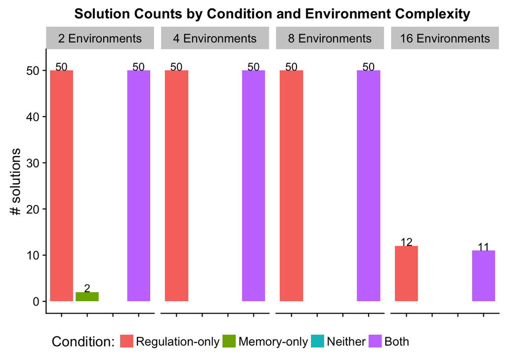

```r
label_lu <- c(
  "2" = "2 Environments",
  "4" = "4 Environments",
  "8" = "8 Environments",
  "16" = "16 Environments",
  "32" ="32 Environments"
)


sol_data <- filter(data, solution=="1")
ggplot(sol_data, aes(x=condition, fill=condition)) +
  geom_bar() +
  geom_text(stat="count", aes(label=..count..), position=position_dodge(0.9), vjust=0) +
  ggtitle("Solution Counts by Condition and Environment Complexity") +
  xlab("Condition") +
  scale_y_continuous(name="# solutions", breaks=seq(0, 50, 10), limits=c(0, 52)) +
  scale_fill_discrete(name="Condition:",
                      limits=c("regulation", "memory", "none", "both"),
                      labels=c("Regulation-only", "Memory-only", "Neither", "Both")) +
  scale_x_discrete(limits=c("regulation", "memory", "none", "both"),
                   labels=c("Regulation", "Memory", "Neither", "Both")) +
  facet_wrap(~ NUM_SIGNAL_RESPONSES, nrow=1, labeller=labeller(NUM_SIGNAL_RESPONSES=label_lu)) +
  theme(legend.position="bottom", axis.text.x=element_blank(), axis.title.x=element_blank()) +
  ggsave("./imgs/repeated-signal-solultion-cnts.png", width=8,height=3)
```

Note that in the lowest-complexity environment ($K=2$), two runs using classic SignalGP digital organisms produce solutions. This, in addition to hand-coded programs, confirms that it is *possible* to solve the repeated signal task without regulation. However, these data seem to indicate that using the global memory buffer as it is currently designed/implemented is more challenging than using function regulation.

We use a Fisher’s exact test to determine if there are significant differences (p < 0.05) between the numbers of solutions found in the regulation-augmented SignalGP condition and all other conditions (within each environment complexity level). We correct for multiple comparisons using the bonferroni method. Indeed, our analyses (given below), confirm our visual intuitions: conditions with access to function regulation outperform those without access to function regulation.

````r
environments <- c("2", "4", "8", "16")

for (env in environments) {

  env_data <- filter(data, NUM_SIGNAL_RESPONSES==env)
  cat("#### Environment ", env, " - statistical analysis of solution counts  \n")
  # Extract successes/fails for each condition.
  mem_success_cnt <- nrow(filter(env_data, solution=="1" & condition=="memory"))
  mem_fail_cnt <- nrow(filter(env_data, condition=="memory")) - mem_success_cnt
  reg_success_cnt <- nrow(filter(env_data, solution=="1" & condition=="regulation"))
  reg_fail_cnt <- nrow(filter(env_data, condition=="regulation")) - reg_success_cnt
  both_success_cnt <- nrow(filter(env_data, solution=="1" & condition=="both"))
  both_fail_cnt <- nrow(filter(env_data, condition=="both")) - both_success_cnt
  none_success_cnt <- nrow(filter(env_data, solution=="1" & condition=="none"))
  none_fail_cnt <- nrow(filter(env_data, condition=="none")) - none_success_cnt

  # Regulation-enabled SGP vs. Classic SGP
  mem_sgp_table <- matrix(c(both_success_cnt, mem_success_cnt, both_fail_cnt, mem_fail_cnt), nrow=2)
  rownames(mem_sgp_table) <- c("both", "mem-only")
  colnames(mem_sgp_table) <- c("success", "fail")
  mem_sgp_fishers <- fisher.test(mem_sgp_table)

  # Regulation-enabled SGP vs. Regulation-only SGP
  reg_sgp_table <- matrix(c(both_success_cnt, reg_success_cnt, both_fail_cnt, reg_fail_cnt), nrow=2)
  rownames(reg_sgp_table) <- c("both", "reg-only")
  colnames(reg_sgp_table) <- c("success", "fail")
  reg_sgp_fishers <- fisher.test(reg_sgp_table)

  # Regulation-enabled SGP vs. No reg/mem SGP
  none_sgp_table <- matrix(c(both_success_cnt, none_success_cnt, both_fail_cnt, none_fail_cnt), nrow=2)
  rownames(none_sgp_table) <- c("both", "none")
  colnames(none_sgp_table) <- c("success", "fail")
  none_sgp_fishers <- fisher.test(none_sgp_table)

  # Adjust for multiple comparisons
  adjusted <- p.adjust(p=c(mem_sgp_fishers$p.value,
                           reg_sgp_fishers$p.value,
                           none_sgp_fishers$p.value), method=correction_method)
  mem_sgp_fishers$p.adjusted <- adjusted[1]
  reg_sgp_fishers$p.adjusted <- adjusted[2]
  none_sgp_fishers$p.adjusted <- adjusted[3]

  # Summarize!
  no_sig_comps <- TRUE
  cat("Significant comparisons (Fisher's exact test, p < ", alpha, ",", correction_method, " correction for multiple comparisons):  \n\n")
  if (mem_sgp_fishers$p.adjusted < alpha) {
    cat("- Regulation-augmented SignalGP (regulation & global memory) vs. Classic SignalGP (global memory only )  \n")
    no_sig_comps <- FALSE
  }
  if (reg_sgp_fishers$p.adjusted < alpha) {
    cat("- Regulation-augmented SignalGP (regulation & global memory) vs. Regulation-only SignalGP (global memory disabled)  \n")
    no_sig_comps <- FALSE
  }
  if (none_sgp_fishers$p.adjusted < alpha) {
    cat("- Regulation-augmented SignalGP (regulation & global memory) vs. Regulation- and Memory-Disabled SignalGP  \n")
    no_sig_comps <- FALSE
  }
  if (no_sig_comps) {
    cat("- NONE  \n")
  }

  cat("\n")
  cat("**Results - Regulation-augmented SignalGP (regulation & global memory) vs. Classic SignalGP (global memory only)**  \n")
  cat("```\n")
  print(mem_sgp_table)
  print(mem_sgp_fishers)
  cat("p.adjusted = ", mem_sgp_fishers$p.adjusted, " (method = ", correction_method, ")", "  \n")
  cat("```\n")

  cat("**Results - Regulation-augmented SignalGP (regulation & global memory) vs. Regulation-only SignalGP (global memory disabled)**  \n")
  cat("```\n")
  print(reg_sgp_table)
  print(reg_sgp_fishers)
  cat("p.adjusted = ", reg_sgp_fishers$p.adjusted, " (method = ", correction_method, ")", "  \n")
  cat("```\n")

  cat("**Results - Regulation-augmented SignalGP (regulation & global memory) vs. Regulation- and Memory-Disabled SignalGP**  \n")
  cat("```\n")
  print(none_sgp_table)
  print(none_sgp_fishers)
  cat("p.adjusted = ", none_sgp_fishers$p.adjusted, " (method = ", correction_method,")", "  \n")
  cat("```\n")
  cat("\n")

}
````

#### Environment 2 - statistical analysis of solution counts

Significant comparisons (Fisher’s exact test, p < 0.05 , bonferroni correction for multiple comparisons):

- Regulation-augmented SignalGP (regulation & global memory) vs. Classic SignalGP (global memory only )
- Regulation-augmented SignalGP (regulation & global memory) vs. Regulation- and Memory-Disabled SignalGP

**Results - Regulation-augmented SignalGP (regulation & global memory) vs. Classic SignalGP (global memory only)**

```
         success fail
both          50    0
mem-only       2   48

    Fisher's Exact Test for Count Data

data:  mem_sgp_table
p-value < 2.2e-16
alternative hypothesis: true odds ratio is not equal to 1
95 percent confidence interval:
 144.1219      Inf
sample estimates:
odds ratio
       Inf

p.adjusted =  7.885711e-26  (method =  bonferroni )
```

**Results - Regulation-augmented SignalGP (regulation & global memory) vs. Regulation-only SignalGP (global memory disabled)**

```
         success fail
both          50    0
reg-only      50    0

    Fisher's Exact Test for Count Data

data:  reg_sgp_table
p-value = 1
alternative hypothesis: true odds ratio is not equal to 1
95 percent confidence interval:
   0 Inf
sample estimates:
odds ratio
         0

p.adjusted =  1  (method =  bonferroni )
```

**Results - Regulation-augmented SignalGP (regulation & global memory) vs. Regulation- and Memory-Disabled SignalGP**

```
     success fail
both      50    0
none       0   50

    Fisher's Exact Test for Count Data

data:  none_sgp_table
p-value < 2.2e-16
alternative hypothesis: true odds ratio is not equal to 1
95 percent confidence interval:
 326.3772      Inf
sample estimates:
odds ratio
       Inf

p.adjusted =  5.946992e-29  (method =  bonferroni )
```

#### Environment 4 - statistical analysis of solution counts

Significant comparisons (Fisher’s exact test, p < 0.05 , bonferroni correction for multiple comparisons):

- Regulation-augmented SignalGP (regulation & global memory) vs. Classic SignalGP (global memory only )
- Regulation-augmented SignalGP (regulation & global memory) vs. Regulation- and Memory-Disabled SignalGP

**Results - Regulation-augmented SignalGP (regulation & global memory) vs. Classic SignalGP (global memory only)**

```
         success fail
both          50    0
mem-only       0   50

    Fisher's Exact Test for Count Data

data:  mem_sgp_table
p-value < 2.2e-16
alternative hypothesis: true odds ratio is not equal to 1
95 percent confidence interval:
 326.3772      Inf
sample estimates:
odds ratio
       Inf

p.adjusted =  5.946992e-29  (method =  bonferroni )
```

**Results - Regulation-augmented SignalGP (regulation & global memory) vs. Regulation-only SignalGP (global memory disabled)**

```
         success fail
both          50    0
reg-only      50    0

    Fisher's Exact Test for Count Data

data:  reg_sgp_table
p-value = 1
alternative hypothesis: true odds ratio is not equal to 1
95 percent confidence interval:
   0 Inf
sample estimates:
odds ratio
         0

p.adjusted =  1  (method =  bonferroni )
```

**Results - Regulation-augmented SignalGP (regulation & global memory) vs. Regulation- and Memory-Disabled SignalGP**

```
     success fail
both      50    0
none       0   50

    Fisher's Exact Test for Count Data

data:  none_sgp_table
p-value < 2.2e-16
alternative hypothesis: true odds ratio is not equal to 1
95 percent confidence interval:
 326.3772      Inf
sample estimates:
odds ratio
       Inf

p.adjusted =  5.946992e-29  (method =  bonferroni )
```

#### Environment 8 - statistical analysis of solution counts

Significant comparisons (Fisher’s exact test, p < 0.05 , bonferroni correction for multiple comparisons):

- Regulation-augmented SignalGP (regulation & global memory) vs. Classic SignalGP (global memory only )
- Regulation-augmented SignalGP (regulation & global memory) vs. Regulation- and Memory-Disabled SignalGP

**Results - Regulation-augmented SignalGP (regulation & global memory) vs. Classic SignalGP (global memory only)**

```
         success fail
both          50    0
mem-only       0   50

    Fisher's Exact Test for Count Data

data:  mem_sgp_table
p-value < 2.2e-16
alternative hypothesis: true odds ratio is not equal to 1
95 percent confidence interval:
 326.3772      Inf
sample estimates:
odds ratio
       Inf

p.adjusted =  5.946992e-29  (method =  bonferroni )
```

**Results - Regulation-augmented SignalGP (regulation & global memory) vs. Regulation-only SignalGP (global memory disabled)**

```
         success fail
both          50    0
reg-only      50    0

    Fisher's Exact Test for Count Data

data:  reg_sgp_table
p-value = 1
alternative hypothesis: true odds ratio is not equal to 1
95 percent confidence interval:
   0 Inf
sample estimates:
odds ratio
         0

p.adjusted =  1  (method =  bonferroni )
```

**Results - Regulation-augmented SignalGP (regulation & global memory) vs. Regulation- and Memory-Disabled SignalGP**

```
     success fail
both      50    0
none       0   50

    Fisher's Exact Test for Count Data

data:  none_sgp_table
p-value < 2.2e-16
alternative hypothesis: true odds ratio is not equal to 1
95 percent confidence interval:
 326.3772      Inf
sample estimates:
odds ratio
       Inf

p.adjusted =  5.946992e-29  (method =  bonferroni )
```

#### Environment 16 - statistical analysis of solution counts

Significant comparisons (Fisher’s exact test, p < 0.05 , bonferroni correction for multiple comparisons):

- Regulation-augmented SignalGP (regulation & global memory) vs. Classic SignalGP (global memory only )
- Regulation-augmented SignalGP (regulation & global memory) vs. Regulation- and Memory-Disabled SignalGP

**Results - Regulation-augmented SignalGP (regulation & global memory) vs. Classic SignalGP (global memory only)**

```
         success fail
both          11   39
mem-only       0   50

    Fisher's Exact Test for Count Data

data:  mem_sgp_table
p-value = 0.0005275
alternative hypothesis: true odds ratio is not equal to 1
95 percent confidence interval:
 2.949519      Inf
sample estimates:
odds ratio
       Inf

p.adjusted =  0.001582452  (method =  bonferroni )
```

**Results - Regulation-augmented SignalGP (regulation & global memory) vs. Regulation-only SignalGP (global memory disabled)**

```
         success fail
both          11   39
reg-only      12   38

    Fisher's Exact Test for Count Data

data:  reg_sgp_table
p-value = 1
alternative hypothesis: true odds ratio is not equal to 1
95 percent confidence interval:
 0.3147158 2.5188316
sample estimates:
odds ratio
  0.894173

p.adjusted =  1  (method =  bonferroni )
```

**Results - Regulation-augmented SignalGP (regulation & global memory) vs. Regulation- and Memory-Disabled SignalGP**

```
     success fail
both      11   39
none       0   50

    Fisher's Exact Test for Count Data

data:  none_sgp_table
p-value = 0.0005275
alternative hypothesis: true odds ratio is not equal to 1
95 percent confidence interval:
 2.949519      Inf
sample estimates:
odds ratio
       Inf

p.adjusted =  0.001582452  (method =  bonferroni )
```

### Repeated signal task scores by condition

Here, we give the raw task scores for the highest-fitness organism from each run across all environments/conditions.

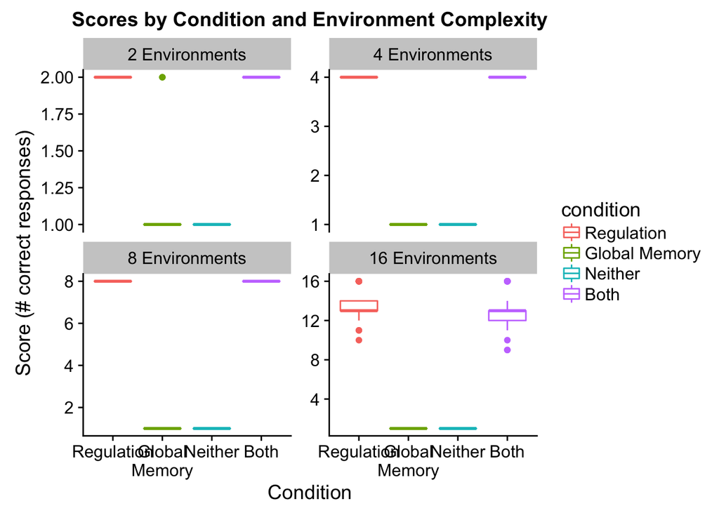

```r
ggplot(data, aes(x=condition, y=score, color=condition)) +
  geom_boxplot() +
  ggtitle("Scores by Condition and Environment Complexity") +
  xlab("Condition") +
  ylab("Score (# correct responses)") +
  scale_color_discrete(breaks=c("regulation", "memory", "none", "both"),
                   labels=c("Regulation", "Global Memory", "Neither", "Both")) +
  scale_x_discrete(breaks=c("regulation", "memory", "none", "both"),
                   labels=c("Regulation", "Global\nMemory", "Neither", "Both")) +
  facet_wrap(~ NUM_SIGNAL_RESPONSES, scales="free_y", labeller=labeller(NUM_SIGNAL_RESPONSES=label_lu)) +
  ggsave("./imgs/repeated-signal-scores.png", width=16,height=8)
```

### How long did it take for solutions to arise?

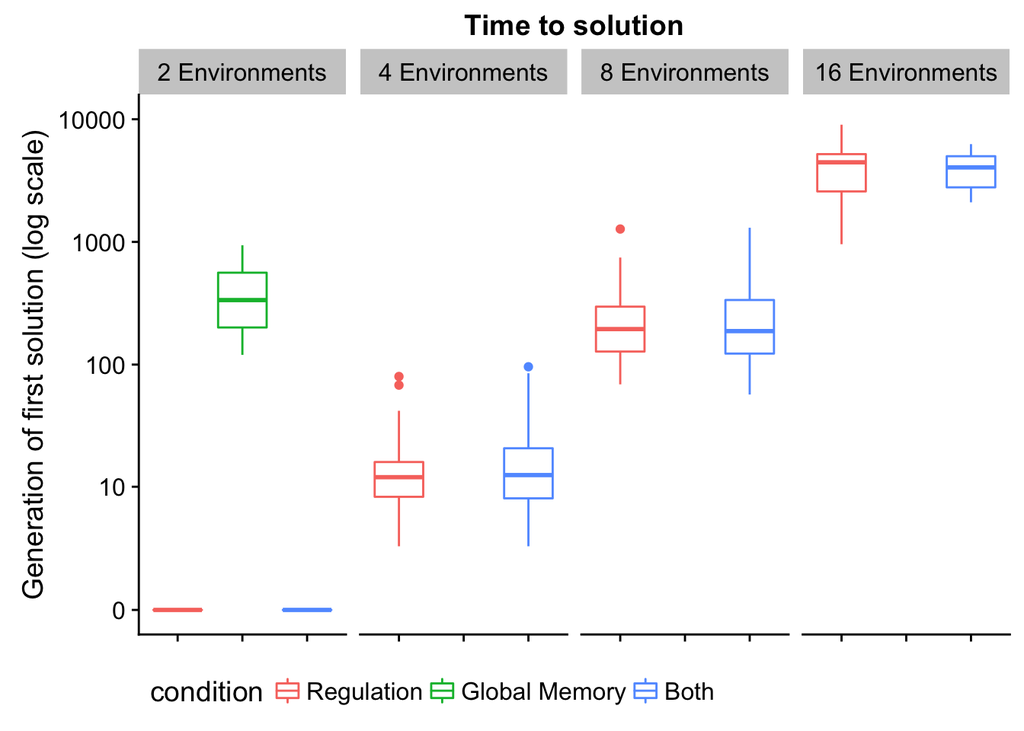

```r
ggplot(filter(data, solution=="1"), aes(x=condition, y=update, color=condition)) +
  geom_boxplot() +
  ggtitle("Time to solution") +
  ylab("Generation of first solution (log scale)") +
  scale_color_discrete(breaks=c("regulation", "memory", "none", "both"),
                   labels=c("Regulation", "Global Memory", "Neither", "Both")) +
  scale_x_discrete(breaks=c("regulation", "memory", "none", "both"),
                   labels=c("Regulation", "Global\nMemory", "Neither", "Both")) +
  scale_y_continuous(limits=c(0, 10000), breaks=c(0, 10, 100, 1000, 10000), trans="pseudo_log")+
  facet_wrap(~ NUM_SIGNAL_RESPONSES, nrow=1, labeller=labeller(NUM_SIGNAL_RESPONSES=label_lu)) +
  theme(legend.position="bottom", axis.text.x=element_blank(), axis.title.x=element_blank()) +
  ggsave("./imgs/repeated-signal-solve-time.png", width=8,height=4)
```

#### 2-state environment

```r
env_2_sol_data <- filter(data, solution=="1" & NUM_SIGNAL_RESPONSES==2)
# First, kruskal-wallis to test for significant differences among groups
env2_kt <- kruskal.test(update ~ condition, data=env_2_sol_data)
print(env2_kt)
```

```
##
##  Kruskal-Wallis rank sum test
##
## data:  update by condition
## Kruskal-Wallis chi-squared = 100.99, df = 2, p-value < 2.2e-16
```

```r
# Next, if kruskal-wallis is significant, perform a pairwise wilcoxon rank-sum test
if (env2_kt$p.value < alpha) {
  # x: response vector; g: grouping vector
  env2_wt <- pairwise.wilcox.test(x=env_2_sol_data$update, g=env_2_sol_data$condition, p.adjust.method="holm", exact=FALSE)
  print(env2_wt)
} else {
  print("No significant difference.")
}
```

```
##
##  Pairwise comparisons using Wilcoxon rank sum test
##
## data:  env_2_sol_data$update and env_2_sol_data$condition
##
##        regulation memory
## memory 3.1e-12    -
## both   -          3.1e-12
##
## P value adjustment method: holm
```

Here, the solutions from regulation-enabled conditions arose sooner than solutions from memory-only conditions.

#### 4-state environment

```r
env_4_sol_data <- filter(data, solution=="1" & NUM_SIGNAL_RESPONSES==4)
# First, kruskal-wallis to test for significant differences among groups
env4_kt <- kruskal.test(update ~ condition, data=env_4_sol_data)
print(env4_kt)
```

```
##
##  Kruskal-Wallis rank sum test
##
## data:  update by condition
## Kruskal-Wallis chi-squared = 0.28629, df = 1, p-value = 0.5926
```

```r
# Next, if kruskal-wallis is significant, perform a pairwise wilcoxon rank-sum test
if (env4_kt$p.value < alpha) {
  # x: response vector; g: grouping vector
  env4_wt <- pairwise.wilcox.test(x=env_4_sol_data$update, g=env_4_sol_data$condition, p.adjust.method="holm", exact=FALSE)
  print(env4_wt)
} else {
  print("No significant difference.")
}
```

```
## [1] "No significant difference."
```

Here, only regulation-enabled treatments yielded solutions, and there is no significant difference between the two regulation-enabled conditions.

#### 8-state environment

```r
env_8_sol_data <- filter(data, solution=="1" & NUM_SIGNAL_RESPONSES==8)
# First, kruskal-wallis to test for significant differences among groups
env8_kt <- kruskal.test(update ~ condition, data=env_8_sol_data)
print(env8_kt)
```

```
##
##  Kruskal-Wallis rank sum test
##
## data:  update by condition
## Kruskal-Wallis chi-squared = 0.14904, df = 1, p-value = 0.6995
```

```r
# Next, if kruskal-wallis is significant, perform a pairwise wilcoxon rank-sum test
if (env8_kt$p.value < alpha) {
  # x: response vector; g: grouping vector
  env8_wt <- pairwise.wilcox.test(x=env_8_sol_data$update, g=env_8_sol_data$condition, p.adjust.method="holm", exact=FALSE)
  print(env8_wt)
} else {
  print("No significant difference.")
}
```

```
## [1] "No significant difference."
```

Here, only regulation-enabled treatments yielded solutions, and there is no significant difference between the two regulation-enabled conditions.

#### 16-state environment

```r
# First, kruskal-wallis to test for significant differences among groups
env_16_sol_data <- filter(data, solution=="1" & NUM_SIGNAL_RESPONSES==16)
env16_kt <- kruskal.test(update ~ condition, data=env_16_sol_data)
print(env16_kt)
```

```
##
##  Kruskal-Wallis rank sum test
##
## data:  update by condition
## Kruskal-Wallis chi-squared = 0, df = 1, p-value = 1
```

```r
# Next, if kruskal-wallis is significant, perform a pairwise wilcoxon rank-sum test
if (env16_kt$p.value < alpha) {
  # x: response vector; g: grouping vector
  env16_wt <- pairwise.wilcox.test(x=env_16_sol_data$update, g=env_16_sol_data$condition, p.adjust.method="holm", exact=FALSE)
  print(env16_wt)
} else {
  print("No significant difference.")
}
```

```
## [1] "No significant difference."
```

Here, only regulation-enabled treatments yielded solutions, and there is no significant difference between the two regulation-enabled conditions.

### When given access to function regulation and global memory, what do solutions rely on?

Here, we take a closer at the strategies employed by solutions evolved across environment complexities. For each evolved solution, we independently knocked out (disabled) function regulation and global memory access. We measured the fitness effects of knocking each of function regulation and global memory, and if a knockout resulted in a decrease in fitness, we labeled that organism as relying on that functionality (global memory or function regulation) for success.

The graph below gives the proportion of solutions that rely on just regulation, just global memory, and both global memory and regulation for each of the regulation-only, global-memory-only (classic SignalGP), and regulation-and-memory (regulation-augmented SignalGP) conditions. We can see that in conditions where organisms have access to either just regulation or both regulation and global memory, evolved solutions rely *only* on regulation. In conditions where memory is the only mechanism for solving the repeated signal task, we see that all evolved solutions (only 2) rely only on memory.

These data show that, in SignalGP’s current configuration of function regulation and global memory, evolution ‘prefers’ function regulation for solving the repeated signal task.

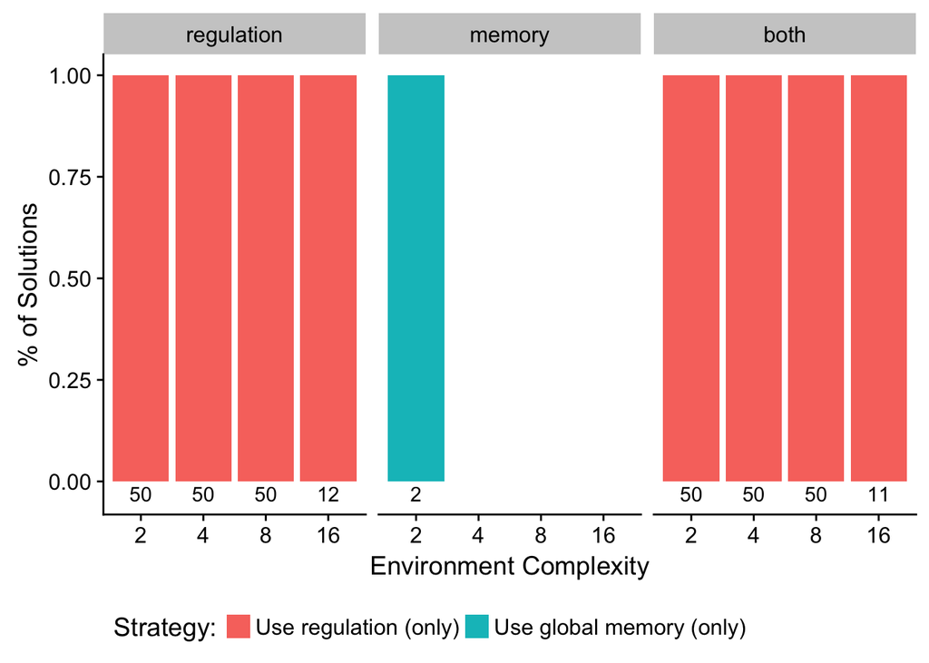

```r
reg_and_mem_solutions <- filter(data, solution=="1")
get_strategy <- function(use_reg, use_mem) {
  if (use_reg=="0" && use_mem=="0") {
    return("use neither")
  } else if (use_reg=="0" && use_mem=="1") {
    return("use memory")
  } else if (use_reg=="1" && use_mem=="0") {
    return("use regulation")
  } else if (use_reg=="1" && use_mem=="1") {
    return("use both")
  } else {
    return("UNKNOWN")
  }
}
# Specify experimental conditions (to make labeling easier).
reg_and_mem_solutions$strategy <- mapply(get_strategy, reg_and_mem_solutions$relies_on_regulation, reg_and_mem_solutions$relies_on_global_memory)
reg_and_mem_solutions$strategy <- factor(reg_and_mem_solutions$strategy, levels=c("use regulation", "use memory", "use neither", "use both"))

ggplot(reg_and_mem_solutions, mapping=aes(x=NUM_SIGNAL_RESPONSES, fill=strategy)) +
  geom_bar(position="fill", stat="count") +
  geom_text(stat='count', mapping=aes(label=..count..), position=position_fill(vjust=-0.03)) +
  ylab("% of Solutions") +
  xlab("Environment Complexity") +
  scale_fill_discrete(name="Strategy:", breaks=c("use regulation", "use memory", "use neither", "use both"),
                   labels=c("Use regulation (only)", "Use global memory (only)", "Use neither", "Use both")) +
  facet_wrap(~condition) +
  theme(legend.position = "bottom") +
  ggsave("./imgs/repeated-signal-strategies.png", width=8,height=4)
```

### Are evolved programs relying on stochastic strategies?

To confirm that evolved organisms were not relying on stochastic approaches to solve the repeated signal task, we tested each of the highest-fitness individuals in the population at the end of each run three times. If an organism’s phenotype was not identical across each of the three trials, we labeled is as using a stochastic strategy. From the graph below, we see no evidence of evolved organisms relying on stochastic strategies to solve the repeated signal task. I.e., all organisms responded consistently across trials. Note, this is unsurprising, as we do not give programs access to instructions capable of generating random values.

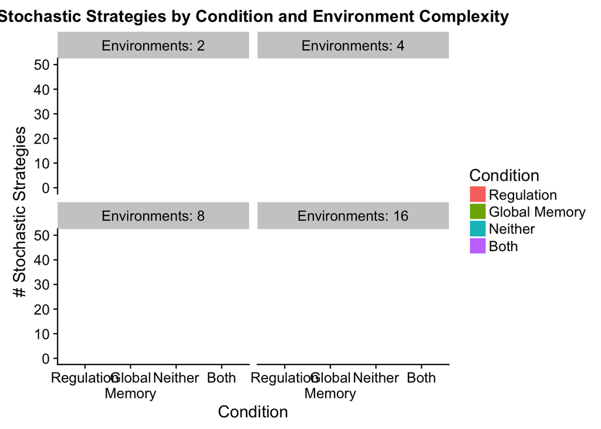

```r
label_lu <- c(
  "2" = "Environments: 2",
  "4" = "Environments: 4",
  "8" = "Environments: 8",
  "16" = "Environments: 16",
  "32" ="Environments: 32"
)

ggplot(filter(data), aes(x=condition, y=stochastic, fill=condition)) +
  geom_bar(stat="identity") +
  ggtitle("Stochastic Strategies by Condition and Environment Complexity") +
  xlab("Condition") +
  ylab("# Stochastic Strategies") +
  ylim(0, 50) +
  scale_fill_discrete(name="Condition",
                      breaks=c("regulation", "memory", "none", "both"),
                      labels=c("Regulation", "Global Memory", "Neither", "Both")) +
  scale_x_discrete(breaks=c("regulation", "memory", "none", "both"),
                   labels=c("Regulation", "Global\nMemory", "Neither", "Both")) +
  facet_wrap(~ NUM_SIGNAL_RESPONSES, labeller=labeller(NUM_SIGNAL_RESPONSES=label_lu))
```

## Case Study: regulation in action

Next, we take a closer look at the behavioral profile of evolved SignalGP organisms.

Coming soon…

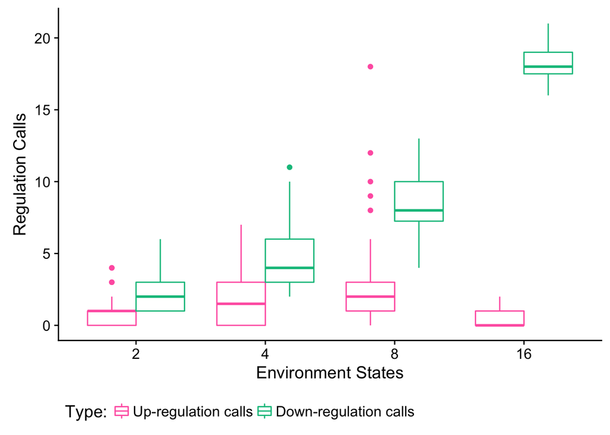

```r
# call_promoted_cnt
# call_repressed_cnt
melted <- melt(filter(data, condition=="both" & solution=="1"),
               variable.name = "call_reg_type",
               value.names = "call_reg_cnt",
               measure.vars=c("call_promoted_cnt", "call_repressed_cnt"))
ggplot(melted, aes(y=value, x=NUM_SIGNAL_RESPONSES, color=call_reg_type)) +
  geom_boxplot() +
  ylab("Regulation Calls") +
  xlab("Environment States") +
  scale_color_discrete(name="Type:", limits=c("call_promoted_cnt", "call_repressed_cnt"), labels=c("Up-regulation calls", "Down-regulation calls"), direction=-1) +
  theme(legend.position="bottom") +
  ggsave("./imgs/repeated-sig-regulate-counts.png", width=6, height=4)
```

```r
  # facet_wrap(~ NUM_SIGNAL_RESPONSES, scales="free_y", labeller=labeller(NUM_SIGNAL_RESPONSES=label_lu))
```